# Analiza wydajności pracowników, oraz nakładów pracy na poszczególne kategorie zadań w Firmie X na przestrzeni lat 2019-2021

## Autor: Marcin Klimczak

# Wprowadzenie

W korporacjach, często można spotkać się z praktyką polegającą na tym, że zadania wykonywane przez pracowników, są po prostu emailami.

Zadanie w rozumieniu korporacyjnym często jest więc zwykłym emailem, zawierającym opis tego, jaki jest problem, który należy rozwiązać.

Dla każdego z tak rozumianych zadań, informacje o przeszłych, już rozwiązanych zadaniach przechoywywane są przez system.

Z tego systemu zostały więc wyciągnięte dane, dla jednego zespołu, na przestrzeni lat 2019-2021

Niepoddany obróbce zbiór danych ma dużo niepotrzebnych zmiennych, i tylko kilka tych interesujących i ważnych. Są to:

- Owner - członek zespołu rozwiązujący zadanie,
- Customer - osoba zlecająca zadanie,
- Category - kategoria do której należy dane zadanie,
- Created on - Data utworzenia zadania
- Resolved on - Data oznaczenia zadania jako zakończone/wykonane.
- RT - resolution time, obliczone jako różnica dat utworzenia i rozwiązania zadania, licząc dzień jako dzień roboczy, czyli jako 8h. Wartości podane są w minutach.

Przykładem obliczania RT niech będzie następujący przypadek:

Zadanie utworzone zostało 10.10.2020r. o godzinie 15:00, i zostało rozwiązane 11.10.2020r. o godzinie 9:00. W związku z tym czas rozwiązania zadania(wartość RT) wynosi 2h czyli 120(minut).

Dane prezentują się następująco:

```
##                  Customer   Owner                Category    Created   Resolved        RT
## 1          Justyna Bylica Marysia         Purchase prices 19.07.2021 20.07.2021  73.00000
## 2        Thi Ngoc Diep Ly Marysia         Purchase prices 19.07.2021 20.07.2021 196.31667
## 3             Berit Mejer  Kamila Sales price Master Data 20.07.2021 20.07.2021  58.73333
## 4 BartJonkers BartJonkers  Kamila         Bank validation 19.07.2021 20.07.2021  38.95000
## 5      Elzbieta Dabrowska    Jola     Purchased materials 31.08.2021 31.08.2021 138.55000
## 6      Elzbieta Dabrowska    Jola     Purchased materials 31.08.2021 31.08.2021 129.15000
```

Tematem analizy, jest wybranie najefektywniejszych i najlepszych pracowników, oraz kateorii zajmujących największy nakład pracy.

W związku z tym, powyższy zbiór danych zawierający 21 795 obserwacji 6 zmiennych opisujących zadanie przekształcono na 2 zbiory - dane zgrupowane wg kategorii oraz wg członków zespołu.

Dla 20 najliczniejszych pod względem całkowitej liczby zadań kategorii, zagregowane dane posiadają następujące zmienne:

- Category - nazwa kategorii,
- mean - średni czas rozwiązywania zadań w danej kategorii,
- count - całkowita ilość zadań w danej kategorii,
- requestors - liczba unikalnych zgłaszających zadania w danej kategorii,
- workers - liczba unikalnych członków zespołu, rozwiązujących zadania w danej kategorii.

Dane prezentują się następująco i będą oznaczane Categories w dalszej części projektu:

```
## # A tibble: 6 x 5
##   Category                 mean count workers requestors
##   <chr>                   <dbl> <int>   <int>      <int>
## 1 Purchased materials     382.   7303      11        286
## 2 Bank validation         408.   2311       9        863
## 3 Purchase prices         242.   2079      10         74
## 4 Vendor in SAP           630.   1404      10        271
## 5 Sales price Master Data  61.6  1260       9         40
## 6 Customer in SAP         407.   1200       8        199
```

Dla członków zespołu, zagregowane dane posiadają następujące zmienne:

- Owner - członek zepsołu,
- mean - średni czas rozwiązywania zadań przez danego członka zespołu,
- count - całkowita ilość zadań rozwiązana przez danego członka zespołu,
- experience - doświadczenie liczone w miesiącach,
- categories - licza unikalnych kategorii, w których członek zespołu rozwiązał conajmniej jedno zadanie

Dane prezentują się następująco i będą oznaczane Owners w dalszej części projektu:

```
## # A tibble: 6 x 5
##   Owner       mean count categories experience
##   <chr>      <dbl> <int>      <int>      <dbl>
## 1 Aleksandra  236.  4275         11         22
## 2 Bartek      550.  1116         29         10
## 3 Filip       464.  3603         17         27
## 4 Jacek       312.   247         17          3
## 5 Jola        136.   205          6          1
## 6 Julia       357.  1574         22         12
```

Z tak przygotowanymi 2 zbiorami zagregowanych danych, można przejść do dalszej analizy.

# Wstępna analiza

Aby stosować metody porządkowania liniowego jak i grupowania, dane muszą spełniać określone kryteria. Ponadto, wstępna analiza w tym przypadku jest kluczowa, ze względu na to, że po niej, jesteśmy w miarę w stanie spodziewać się jakie wyniki uzywkamy.

Poniżej przedstawiono statystyki opisowe dla każdej zmiennej z obu zbiorów danych:

```
##                    mean      count categories experience
## nbr.val           13.00      13.00      13.00      13.00
## nbr.null           0.00       0.00       0.00       1.00
## nbr.na             0.00       0.00       0.00       0.00
## min              135.53       1.00       1.00       0.00
## max             3987.48    4605.00      33.00      28.00
## range           3851.95    4604.00      32.00      28.00
## sum             8721.19   21795.00     215.00     182.00
## median           357.07    1116.00      17.00      12.00
## mean             670.86    1676.54      16.54      14.00
## SE.mean          283.16     487.85       3.00       3.25
## CI.mean.0.95     616.95    1062.93       6.54       7.07
## var          1042321.06 3093947.94     117.10     137.00
## std.dev         1020.94    1758.96      10.82      11.70
## coef.var           1.52       1.05       0.65       0.84
```

```
##                  mean      count workers requestors
## nbr.val         20.00      20.00   20.00      20.00
## nbr.null         0.00       0.00    0.00       0.00
## nbr.na           0.00       0.00    0.00       0.00
## min             61.64      95.00    2.00      18.00
## max            739.07    7303.00   11.00     863.00
## range          677.43    7208.00    9.00     845.00
## sum           7732.90   21436.00  151.00    2844.00
## median         384.59     542.50    7.00      52.50
## mean           386.65    1071.80    7.55     142.20
## SE.mean         45.29     356.37    0.48      44.45
## CI.mean.0.95    94.79     745.90    1.01      93.03
## var          41019.27 2540048.91    4.68   39509.75
## std.dev        202.53    1593.75    2.16     198.77
## coef.var         0.52       1.49    0.29       1.40
```

Na podstawie powyższych tabel można stwierdzić, że wszystkie zmienne mają w miarę wysokie (>10%) współczynniki zmienności.

Na poniższych wykresach, można zobaczyć jak prezentują się histogramy, korelacje, i rozrzuty zmiennych zawartych w każdym ze zbiorów.

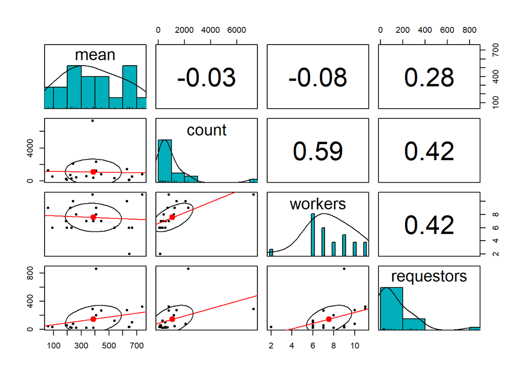

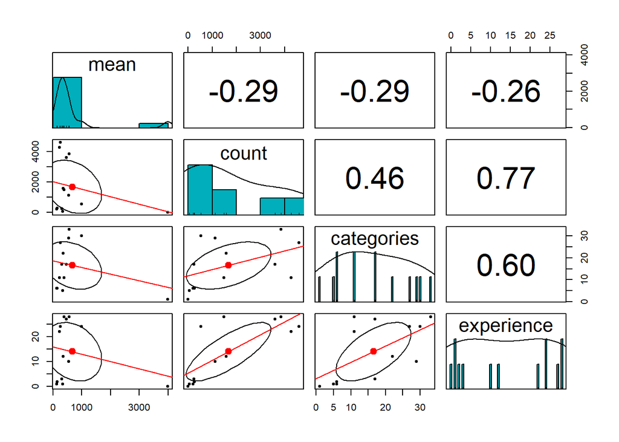

Przed tym procesem jednak, na podstawie porównania poniższych wykresów z wartoścami zawartymi w tabelach powyżej, można zobaczyć jak na tle grupy i indywidualnie wypadają dane kategorie czy członkowie zespołu.

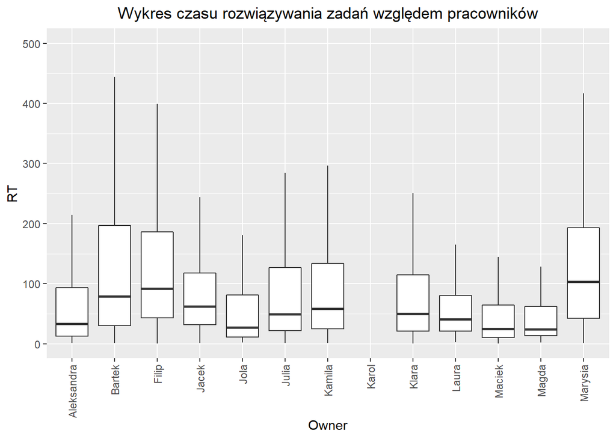

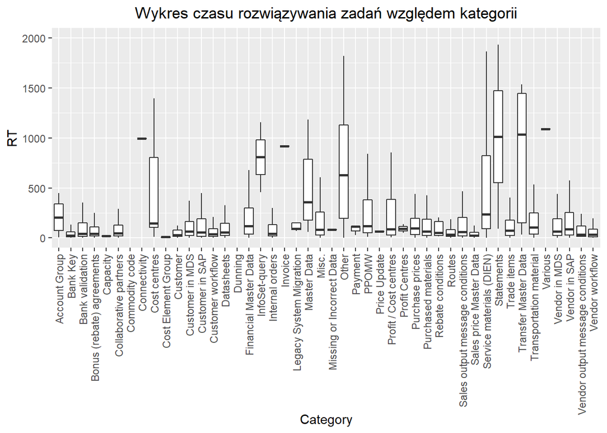

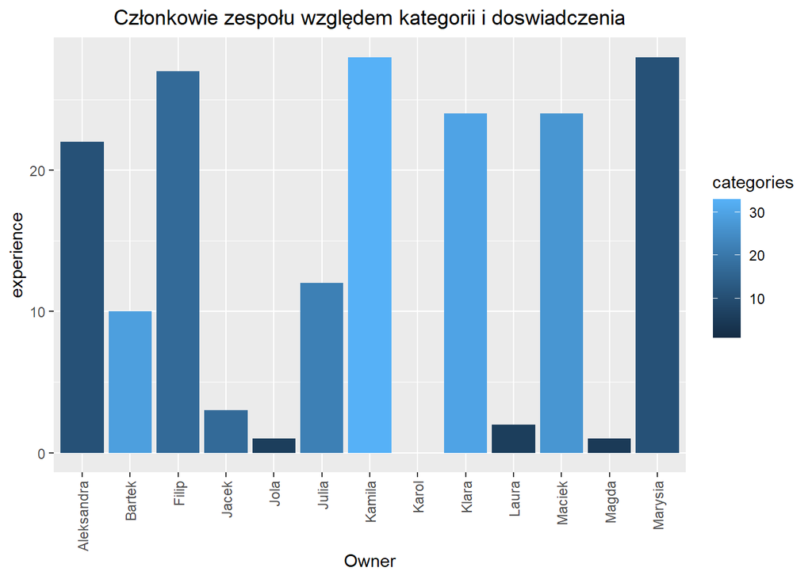

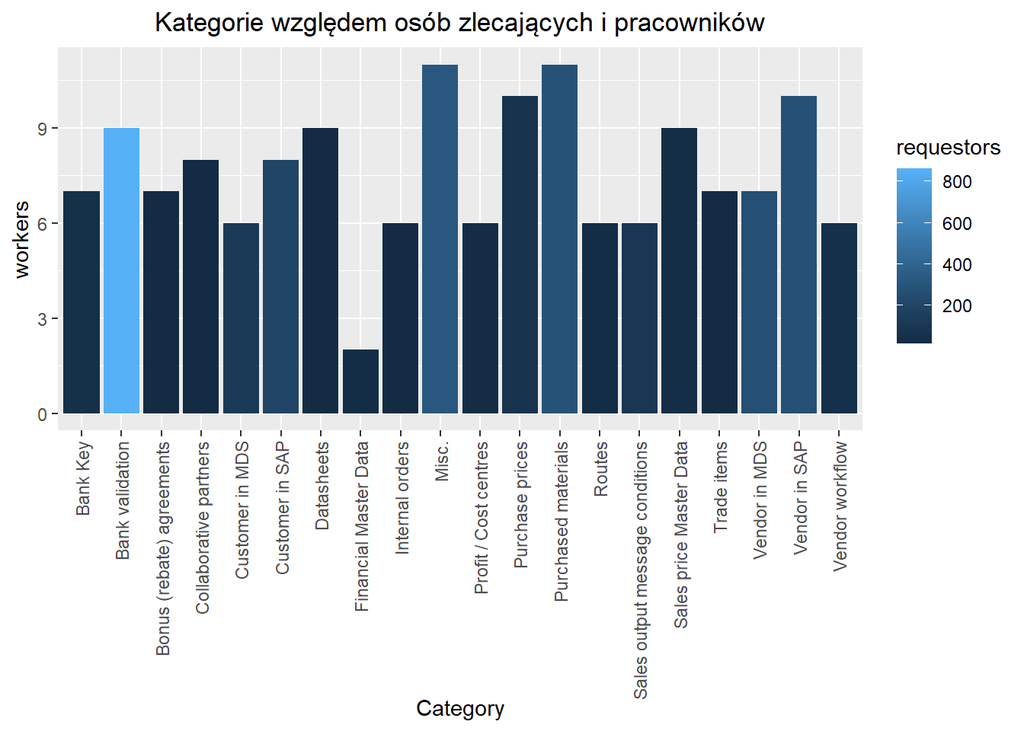

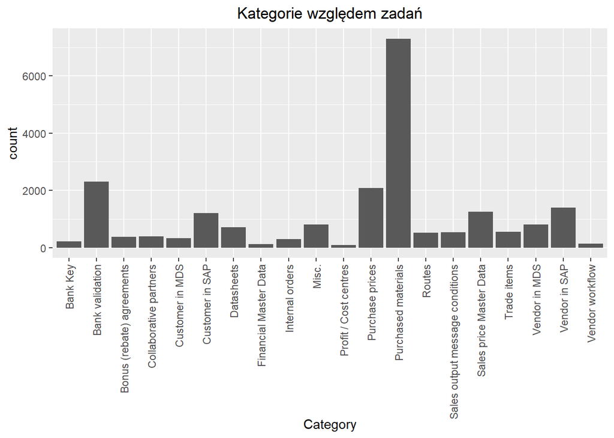

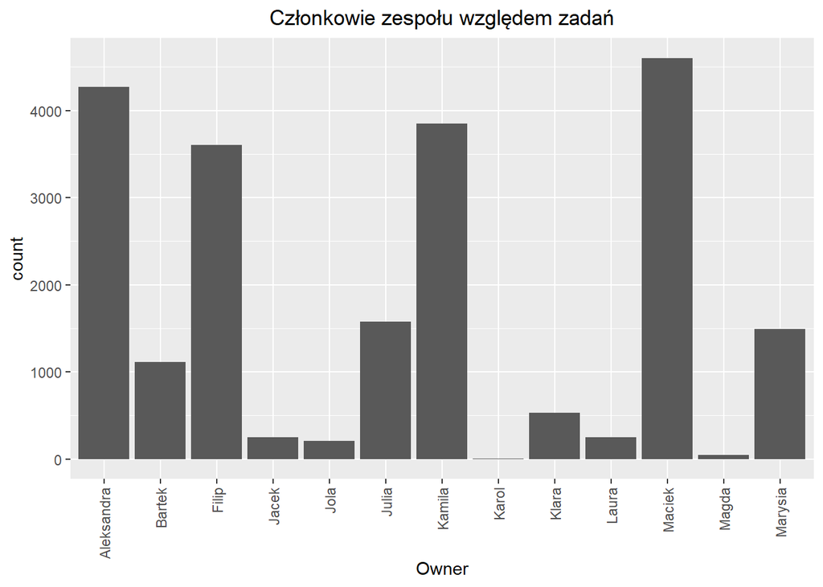

Z analizy samych wykresów wynika, że biorąc pod uwagę ilość zadań wygrywa kategoria Purchased Materials, a z pracowników Maciek. W przypadku kategorii zarówno jak i Purchased materials, kategoria Bank validations rówznież zdecydowanie wybija się na tle innych dzięki największej ilości unikalnych osób zgłaszających zadania. Mozna więc wysunąć wniosek, że przy tak licznej przewadze w dwóch zmiennych, to właśnie jedna, lub obie kategorie znajdą się w czołówce rankingu.

Wartą wspomnienia rzeczą, jest też to, że wykresy RT dla kategorii są bardzo rozbiezne. Podczas gdy większość kategorii oscyluje wokoło zera, inne są bardzo rozciągnięte.

# Porządkowanie liniowe

Przedstawione zostaną dwie metody porządkowania liniowego:

- metoda Hellwiga
- metoda TOPSIS

Pierwszym krokiem jest przekształcenie zmiennych na stymulanty:

- W przypadku zbioru danych Owners - jedynie zmienna mean jest destymulantą, ponieważ im mniejszy średni czas wykonania zadania, tym lepiej.
- W przypadku zbioru danych Categories - jedynie zmienna workers jest destymulatną. W tym wypadku przeprowadzane badanie ma dać odpowiedź, która z kategorii wymaga największego nakładu pracy. Zatem im mniej pracowników w danej kategorii, tym gorzej.

W przypadku pozostałych zmiennych dla obu zbiorów danch, są one wszystkie stymulantami (im więcej tym lepiej)

Następnym krokiem jest standaryzacja zmiannych. W tabeli poniżej można zobaczyć jak prezentują się dane po przeształceniach:

```
## # A tibble: 6 x 5
##   Owner       mean   count categories experience
##   <chr>      <dbl>   <dbl>      <dbl>      <dbl>
## 1 Aleksandra 0.426  1.48      -0.512       0.683
## 2 Bartek     0.119 -0.319      1.15       -0.342
## 3 Filip      0.203  1.10       0.0427      1.11
## 4 Jacek      0.352 -0.813      0.0427     -0.940
## 5 Jola       0.524 -0.837     -0.974      -1.11
## 6 Julia      0.307 -0.0583     0.505      -0.171
```

```
## # A tibble: 6 x 5
##   Category                   mean  count workers requestors
##   <chr>                     <dbl>  <dbl>   <dbl>      <dbl>
## 1 Purchased materials     -0.0243 3.91    -1.59       0.723
## 2 Bank validation          0.107  0.778   -0.670      3.63
## 3 Purchase prices         -0.713  0.632   -1.13      -0.343
## 4 Vendor in SAP            1.20   0.208   -1.13       0.648
## 5 Sales price Master Data -1.60   0.118   -0.670     -0.514
## 6 Customer in SAP          0.102  0.0804  -0.208      0.286
```

## Metoda Helwiga

Zarówno dla zbioru Owners, jak i zbioru Categories, po standaryzacji wyznaczany jest wzór - jako najlepsze wartości każdej ze zmiennych, wzorami w przypadku Owners i Categories są:

```
## # A tibble: 1 x 4
##    mean count workers requestors
##   <dbl> <dbl>   <dbl>      <dbl>
## 1  1.74  3.91    2.57       3.63
```

```
## # A tibble: 1 x 4
##    mean count categories experience
##   <dbl> <dbl>      <dbl>      <dbl>
## 1 0.524  1.66       1.52       1.20
```

Następnie liczone są odległości każdej ze zmiennych od wzorca, wyznaczana jest tzw. odległość maksymalna, a następnie na jej podstawie obliczna są wartości rankingu.

```
## # A tibble: 13 x 7
##    Owner        mean   count categories experience   dist    val
##    <chr>       <dbl>   <dbl>      <dbl>      <dbl>  <dbl>  <dbl>
##  1 Kamila      0.111  1.23       1.52        1.20   0.356  0.988
##  2 Maciek      0.408  1.66       0.967       0.854  0.438  0.986
##  3 Filip       0.203  1.10       0.0427      1.11   2.62   0.913
##  4 Aleksandra  0.426  1.48      -0.512       0.683  4.44   0.853
##  5 Julia       0.307 -0.0583     0.505      -0.171  5.92   0.804
##  6 Klara      -0.312 -0.650      1.24        0.854  6.25   0.793
##  7 Bartek      0.119 -0.319      1.15       -0.342  6.60   0.782
##  8 Marysia     0.281 -0.106     -0.512       1.20   7.33   0.758
##  9 Jacek       0.352 -0.813      0.0427     -0.940 12.9    0.573
## 10 Laura       0.507 -0.809     -0.974      -1.03  17.3    0.428
## 11 Jola        0.524 -0.837     -0.974      -1.11  17.8    0.411
## 12 Magda       0.323 -0.928     -1.07       -1.11  18.8    0.379
## 13 Karol      -3.25  -0.953     -1.44       -1.20  35.6   -0.176
```

```
## # A tibble: 20 x 7
##    Category                            mean   count workers requestors  dist    val
##    <chr>                              <dbl>   <dbl>   <dbl>      <dbl> <dbl>  <dbl>
##  1 Bank validation                  0.107    0.778   -0.670     3.63    22.9 0.604
##  2 Purchased materials             -0.0243   3.91    -1.59      0.723   28.8 0.502
##  3 Vendor in MDS                    0.289   -0.165    0.254     0.618   33.1 0.429
##  4 Customer in SAP                  0.102    0.0804  -0.208     0.286   36.2 0.375
##  5 Sales output message conditions  1.38    -0.341    0.716    -0.232   36.5 0.370
##  6 Vendor in SAP                    1.20     0.208   -1.13      0.648   36.5 0.369
##  7 Customer in MDS                  0.758   -0.470    0.716    -0.0966  37.4 0.354
##  8 Financial Master Data            1.28    -0.593    2.57     -0.544   37.9 0.346
##  9 Misc.                            1.74    -0.166   -1.59      0.900   41.4 0.286
## 10 Profit / Cost centres            1.27    -0.613    0.716    -0.570   41.7 0.280
## 11 Trade items                     -0.242   -0.323    0.254    -0.605   45.1 0.222
## 12 Bonus (rebate) agreements        0.00399 -0.436    0.254    -0.625   45.3 0.218
## 13 Purchase prices                 -0.713    0.632   -1.13     -0.343   46.2 0.203
## 14 Internal orders                 -0.772   -0.492    0.716    -0.615   47.1 0.187
## 15 Vendor workflow                 -0.935   -0.590    0.716    -0.449   47.4 0.181
## 16 Bank Key                        -0.970   -0.539    0.254    -0.454   49.1 0.152
## 17 Routes                          -1.45    -0.349    0.716    -0.554   49.2 0.151
## 18 Collaborative partners          -0.609   -0.423   -0.208    -0.610   49.9 0.138
## 19 Datasheets                      -0.816   -0.227   -0.670    -0.590   51.9 0.104
## 20 Sales price Master Data         -1.60     0.118   -0.670    -0.514   53.2 0.0820
```

Ponieważ powyższe tabele zostały posortowane względem wartości zmiennej odpowiedzialnej za ranking, można zobaczyć, że najlepszym pracownikiem jest:

- Kamila,

A kategorią najbardziej wymagającą jest:

- Bank Validation

Na samym końcu zotało wykonane grupowanie kategorii i członków zespołu na 4 grupy, od najlepszej do najgorszej:

Pogrupowane dane mają następującą postać:

```
## # A tibble: 20 x 8
##    Category                            mean   count workers requestors  dist    val group
##    <chr>                              <dbl>   <dbl>   <dbl>      <dbl> <dbl>  <dbl> <dbl>
##  1 Bank validation                  0.107    0.778   -0.670     3.63    22.9 0.604      1
##  2 Purchased materials             -0.0243   3.91    -1.59      0.723   28.8 0.502      1
##  3 Vendor in MDS                    0.289   -0.165    0.254     0.618   33.1 0.429      1
##  4 Customer in SAP                  0.102    0.0804  -0.208     0.286   36.2 0.375      2
##  5 Sales output message conditions  1.38    -0.341    0.716    -0.232   36.5 0.370      2
##  6 Vendor in SAP                    1.20     0.208   -1.13      0.648   36.5 0.369      2
##  7 Customer in MDS                  0.758   -0.470    0.716    -0.0966  37.4 0.354      2
##  8 Financial Master Data            1.28    -0.593    2.57     -0.544   37.9 0.346      2
##  9 Misc.                            1.74    -0.166   -1.59      0.900   41.4 0.286      2
## 10 Profit / Cost centres            1.27    -0.613    0.716    -0.570   41.7 0.280      2
## 11 Trade items                     -0.242   -0.323    0.254    -0.605   45.1 0.222      3
## 12 Bonus (rebate) agreements        0.00399 -0.436    0.254    -0.625   45.3 0.218      3
## 13 Purchase prices                 -0.713    0.632   -1.13     -0.343   46.2 0.203      3
## 14 Internal orders                 -0.772   -0.492    0.716    -0.615   47.1 0.187      3
## 15 Vendor workflow                 -0.935   -0.590    0.716    -0.449   47.4 0.181      3
## 16 Bank Key                        -0.970   -0.539    0.254    -0.454   49.1 0.152      3
## 17 Routes                          -1.45    -0.349    0.716    -0.554   49.2 0.151      3
## 18 Collaborative partners          -0.609   -0.423   -0.208    -0.610   49.9 0.138      4
## 19 Datasheets                      -0.816   -0.227   -0.670    -0.590   51.9 0.104      4
## 20 Sales price Master Data         -1.60     0.118   -0.670    -0.514   53.2 0.0820     4
```

```
## # A tibble: 13 x 8
##    Owner        mean   count categories experience   dist    val group
##    <chr>       <dbl>   <dbl>      <dbl>      <dbl>  <dbl>  <dbl> <dbl>
##  1 Kamila      0.111  1.23       1.52        1.20   0.356  0.988     1
##  2 Maciek      0.408  1.66       0.967       0.854  0.438  0.986     1
##  3 Filip       0.203  1.10       0.0427      1.11   2.62   0.913     2
##  4 Aleksandra  0.426  1.48      -0.512       0.683  4.44   0.853     2
##  5 Julia       0.307 -0.0583     0.505      -0.171  5.92   0.804     2
##  6 Klara      -0.312 -0.650      1.24        0.854  6.25   0.793     2
##  7 Bartek      0.119 -0.319      1.15       -0.342  6.60   0.782     2
##  8 Marysia     0.281 -0.106     -0.512       1.20   7.33   0.758     2
##  9 Jacek       0.352 -0.813      0.0427     -0.940 12.9    0.573     3
## 10 Laura       0.507 -0.809     -0.974      -1.03  17.3    0.428     3
## 11 Jola        0.524 -0.837     -0.974      -1.11  17.8    0.411     3
## 12 Magda       0.323 -0.928     -1.07       -1.11  18.8    0.379     3
## 13 Karol      -3.25  -0.953     -1.44       -1.20  35.6   -0.176     4
```

Można więc powiedzieć, że według rankingu utworzonego metodą Helwiga, najlepszymi pracownikami są:

- Kamila i Maciek,

A najbardziej wymagającymi w sensie nadładu pracy kategoriami, są:

- Bank Validation oraz Purchased Materials.

Warto także wspomnieć, że najmniej efektywnym pracownikiem okazał się Karol, a kategorie które wymagają najmniejszych nakładów pracy to: Sales price Master Data, oraz Datasheets. Jednak poniewaz nie wszystkie kategorie zostały wzięte pod uwage w analizie, stwierdzenie, że kategorie te są najmniej wymagające wymagałoby dodatkowej analizy ze wszystkimi 46 kategoriami.

## Metoda TOPSIS

Początkowe kroki tej metody, są podobne do metody Helwiga, jednak różnica pojawia się w momencie wyznaczania odległości od wzorca. W metodzie TOPSIS wyznaczany bowiem jest także antywzorzec, a odległość całkowita, na podstawie któej powstaje ranking, uwzględnia zarówno odległośc od wzorca, jak i odległość od antywzorca.

Poniżej można zobaczyć już pogrupowane wyniki:

```
## # A tibble: 13 x 9
##    Owner        mean   count categories experience  dist1 dist2   val group
##    <chr>       <dbl>   <dbl>      <dbl>      <dbl>  <dbl> <dbl> <dbl> <dbl>
##  1 Kamila      0.111  1.23       1.52        1.20   0.356  30.5 0.988     1
##  2 Maciek      0.408  1.66       0.967       0.854  0.438  30.2 0.986     1
##  3 Filip       0.203  1.10       0.0427      1.11   2.62   23.6 0.900     2
##  4 Aleksandra  0.426  1.48      -0.512       0.683  4.44   23.8 0.843     2
##  5 Klara      -0.312 -0.650      1.24        0.854  6.25   20.1 0.763     2
##  6 Julia       0.307 -0.0583     0.505      -0.171  5.92   18.3 0.755     2
##  7 Bartek      0.119 -0.319      1.15       -0.342  6.60   19.2 0.744     2
##  8 Marysia     0.281 -0.106     -0.512       1.20   7.33   19.8 0.729     2
##  9 Jacek       0.352 -0.813      0.0427     -0.940 12.9    15.2 0.541     3
## 10 Laura       0.507 -0.809     -0.974      -1.03  17.3    14.4 0.454     3
## 11 Jola        0.524 -0.837     -0.974      -1.11  17.8    14.5 0.448     3
## 12 Magda       0.323 -0.928     -1.07       -1.11  18.8    12.9 0.407     3
## 13 Karol      -3.25  -0.953     -1.44       -1.20  35.6     0   0         4
```

```
## # A tibble: 20 x 9
##    Category                            mean   count workers requestors dist1 dist2    val group
##    <chr>                              <dbl>   <dbl>   <dbl>      <dbl> <dbl> <dbl>  <dbl> <dbl>
##  1 Bank validation                  0.107    0.778   -0.670     3.63    22.9 23.8  0.509      1
##  2 Purchased materials             -0.0243   3.91    -1.59      0.723   28.8 24.8  0.462      1
##  3 Financial Master Data            1.28    -0.593    2.57     -0.544   37.9 25.6  0.404      1
##  4 Sales output message conditions  1.38    -0.341    0.716    -0.232   36.5 14.5  0.284      2
##  5 Misc.                            1.74    -0.166   -1.59      0.900   41.4 13.7  0.249      2
##  6 Profit / Cost centres            1.27    -0.613    0.716    -0.570   41.7 13.6  0.246      2
##  7 Customer in MDS                  0.758   -0.470    0.716    -0.0966  37.4 11.2  0.231      2
##  8 Vendor in SAP                    1.20     0.208   -1.13      0.648   36.5 10.4  0.221      2
##  9 Vendor in MDS                    0.289   -0.165    0.254     0.618   33.1  8.75 0.209      2
## 10 Customer in SAP                  0.102    0.0804  -0.208     0.286   36.2  6.14 0.145      3
## 11 Bonus (rebate) agreements        0.00399 -0.436    0.254    -0.625   45.3  6.04 0.118      3
## 12 Internal orders                 -0.772   -0.492    0.716    -0.615   47.1  6.05 0.114      3
## 13 Vendor workflow                 -0.935   -0.590    0.716    -0.449   47.4  5.82 0.109      3
## 14 Trade items                     -0.242   -0.323    0.254    -0.605   45.1  5.36 0.106      3
## 15 Routes                          -1.45    -0.349    0.716    -0.554   49.2  5.44 0.0996     3
## 16 Bank Key                        -0.970   -0.539    0.254    -0.454   49.1  3.86 0.0728     3
## 17 Collaborative partners          -0.609   -0.423   -0.208    -0.610   49.9  2.95 0.0558     3
## 18 Purchase prices                 -0.713    0.632   -1.13     -0.343   46.2  2.64 0.0540     3
## 19 Datasheets                      -0.816   -0.227   -0.670    -0.590   51.9  1.63 0.0304     4
## 20 Sales price Master Data         -1.60     0.118   -0.670    -0.514   53.2  1.40 0.0257     4
```

W przypadku Metody TOPSIS, czołówki oraz końcówki nie uległy zmianie.

Można zatem powiedzieć, że metoda TOPSIS potwierdza zarówno najlepsze i najgorsze wyniki w rankingku osiągnięte metodą Helwiga.

# Grupowanie klasyczne i hierarchiczne

Po wykonanym porządkowaniu liniowym, następnym elementem projektu będzie sprawdzenie jak bardzo podobne czy różne od siebie są kategorie, a także gdzie i jak doszukiwać się podobieństw i różnic między członkami zespołu.

# Metoda k-średnich

Grupowanie metodą k-średnich opiera się na tzw. odległościach. Te ogległości liczone są dla każdego porównywanego obiektu (w przypadku tego projektu obiektami są kategorie oraz członkowie zespołu) i dla każdej zmiennej osobno. Tj jeśli dwie kategorie mają podobną wartość jednej zmiennej, dystans między nimi będzie mały, a obiekty będą uważane za podobne.

Przy grupowaniu jednak, brane jest pod uwagę więcej zmiennych, a na podstawie odległości między nimi, można obiekty podzielic na grupy.

W przypadku metody k-średnich, punkty środki skupień dla grup, są zawsze obliczane jako średnie dla poszczególnych zmiennych obiektów.

Poniżej można zobaczyć, jak względem zmiennych count i mean podobni są do siebie zarówno członkowie zespołu, jak i kategorie. Przed tym jednak, nalezy wybrac odpowiednią ilość skupień, czyli grup, na które dzielone będą dane. W tym celu, można sprawdzić, o ile średnio spada wewnątrzgrupowa wariancja zmiennych. Na poniższym wykresie przedstawiono wyskres średniej wartości wariancji wewnątrzgrupowej w zależności od ilości grup na które dzielona jest próbka.

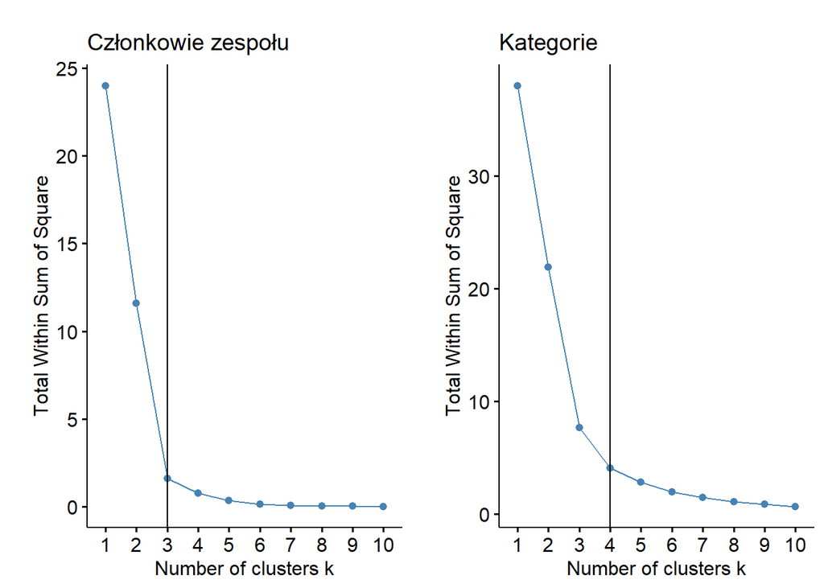

Według danych z powyższych wykresów, chcąc grupować członków zespołu i kategorie, powinno podzielić się członków zespołu na 3 grupy, a kategorie na 4 grupy.

Poniżej mozna zobaczyć wykresy prezentujące takie podziały.

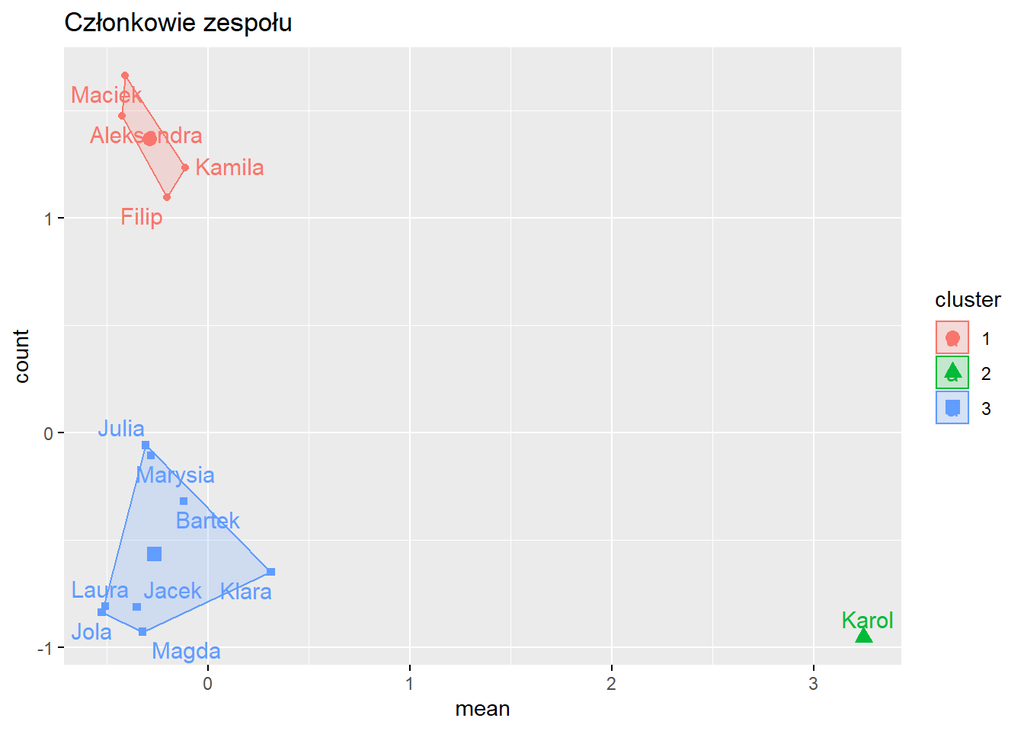

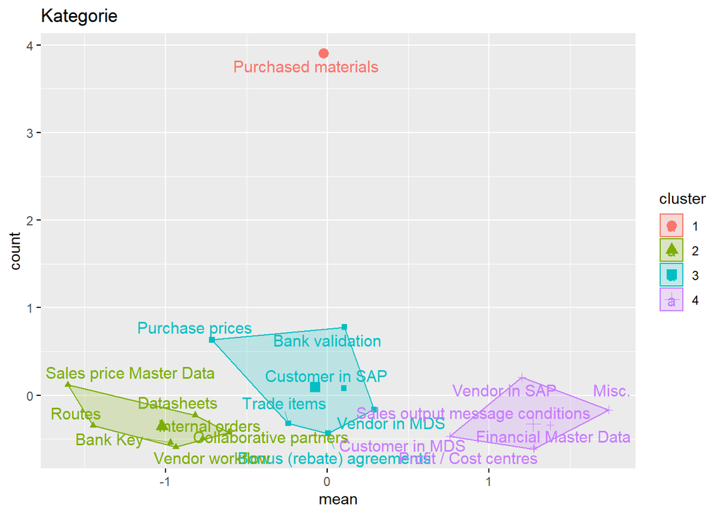

Grupując kategorie ze względu na ilość oraz czas rozwiązywanych zadań z kolei, nie da się jednonacznie stwierdzić, któRa z grup wymaga największego nakładu pracy. Mozna jedynie insynuować, że grupa zielona, jest grupą w miarę bezpieczną.

- Dla członków zespołu - experience oraz categories,
- Dla kategorii - requestors oraz workers.

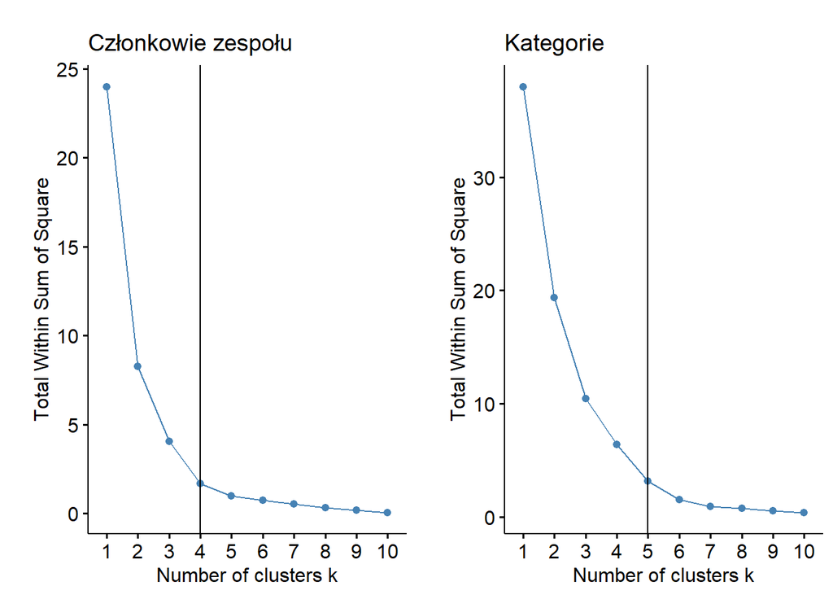

Tym razem, grupowania zostną wykonane na odpowiednio 4 i 5 grup.

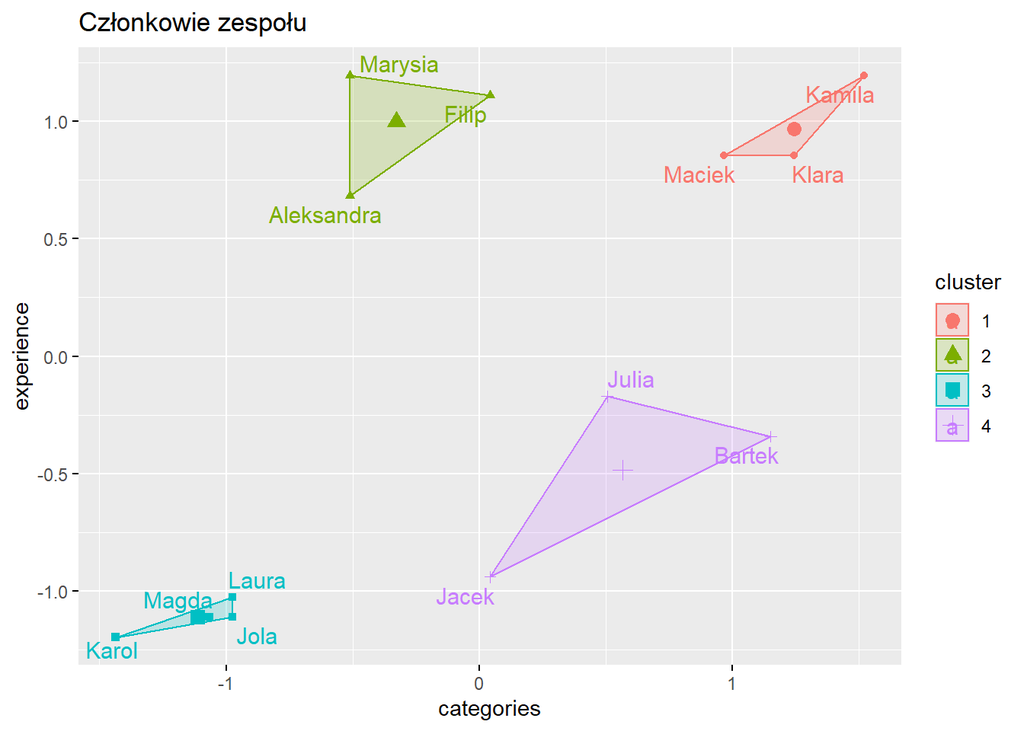

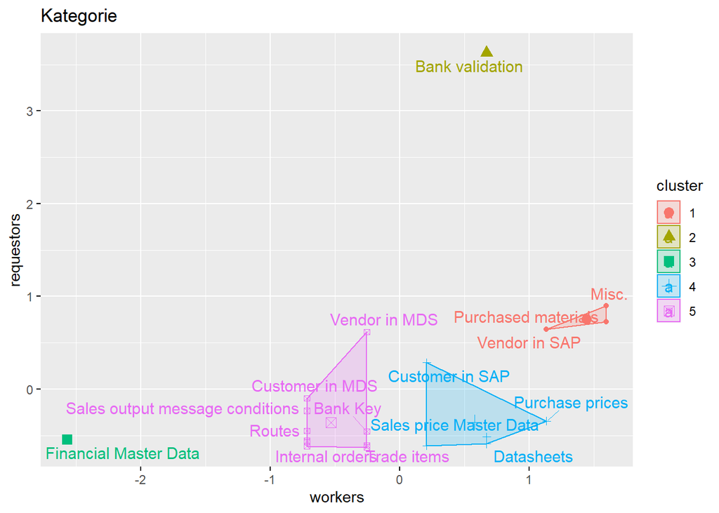

Na podstawie powyższych wykresów, można stwierdzić, że nie ma jednoznacznie wybijających się czy podobnych do siebie zmiennych względem wszystkich zmiennych, zarówno dla członków zespołu, jak i dla kategorii. Aby sprawdzić jak kategorie czy członkowie zespołu są sobie podobni ze względu na wszystkie zmienne będzie trzeba wykorzystać skalowanie wielowymiarowe.

# Metoda PAM

W przypadku metody PAM, środkiem danej grupy nie jest już średnia, a zawsze realna wartość któregoś z obiektów wybranego na środek grupy.

Dla metody PAM wykonano jedynie grupowanie względem zmiennych count oraz mean, w celu porównania jakości grupowania z metodą k-średnich.

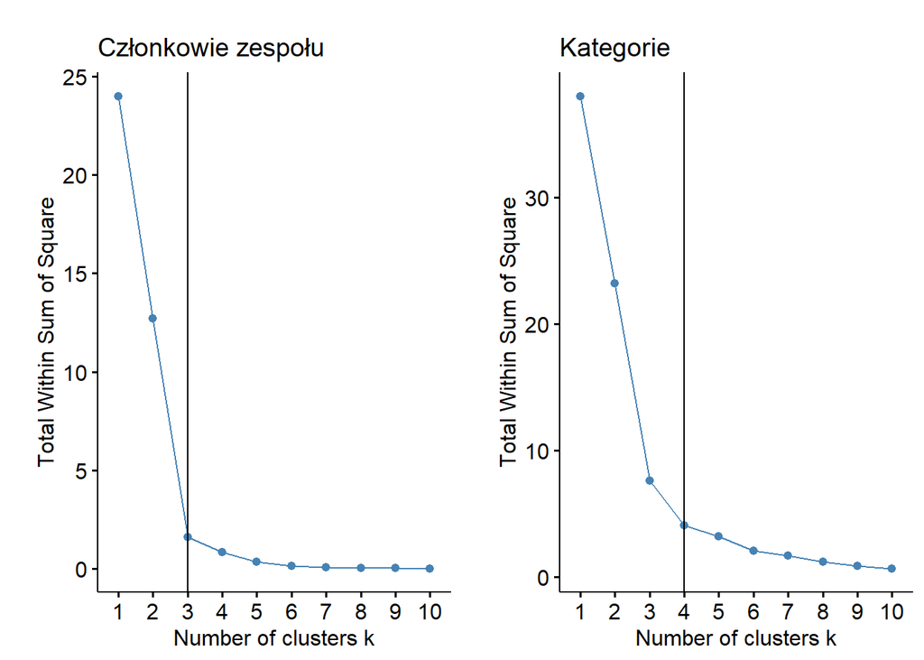

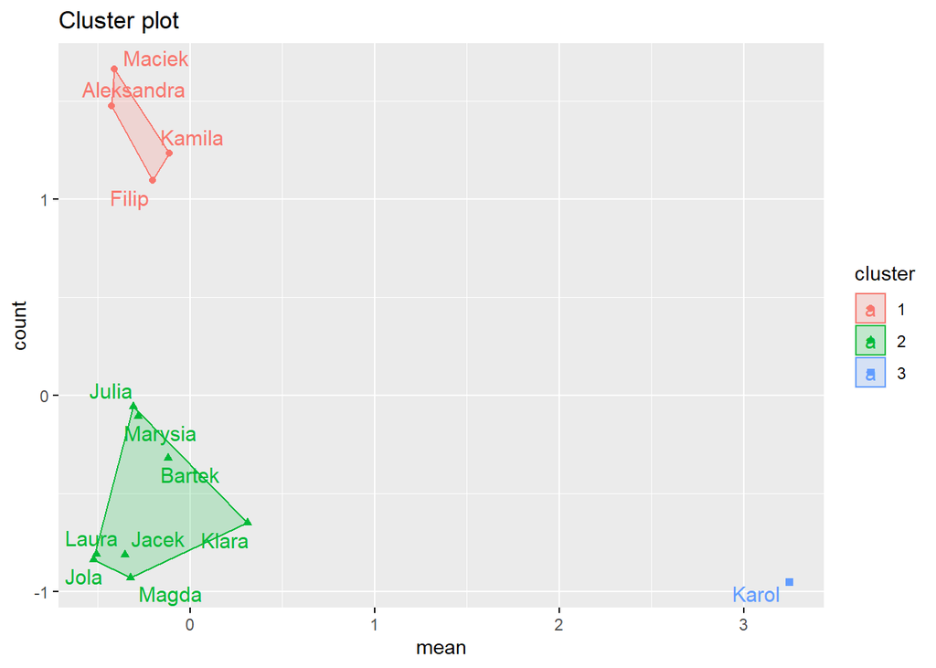

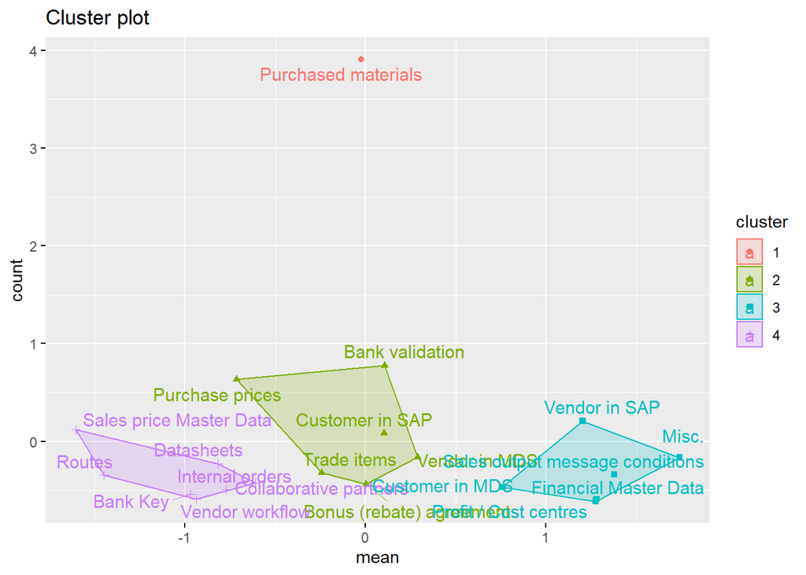

Ostatecznie wykresy nie różnią się w ogóle, zarówno dobrana ilość grup jest taka sama jak i podział na nie. Poniżej mozna zobaczyć dokładne porównanie:

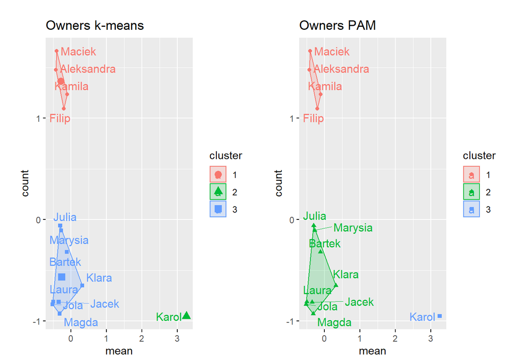

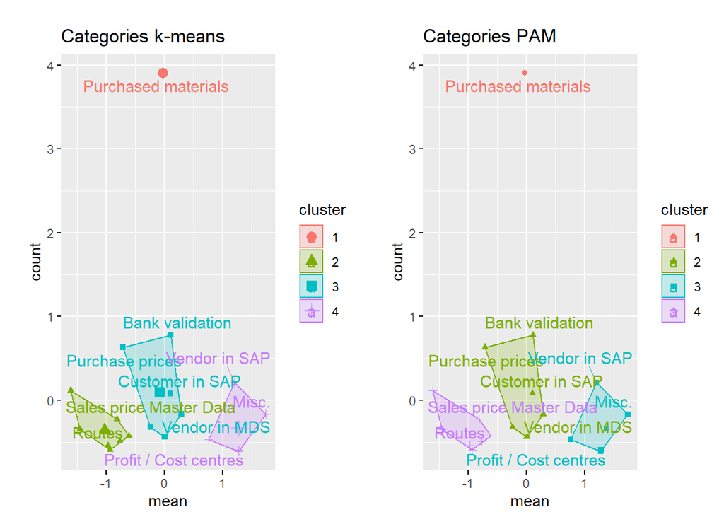

# Grupowanie Hierarchiczne

Jest to metoda aglomeracyjna, któRa wykorzystując odległość wspomnianą wcześniej, zbiera elementy w zoraz większe grupy. Wadą tej metody jest to, że wzajemnie izolowane i niepowiązane ze sobą grupy, mogą być zawarte w jednej większej.

Poniżej zostało wykonane grupowanie hierarchiczne używając dystansu euklidowskiego, medotą k-średnich.

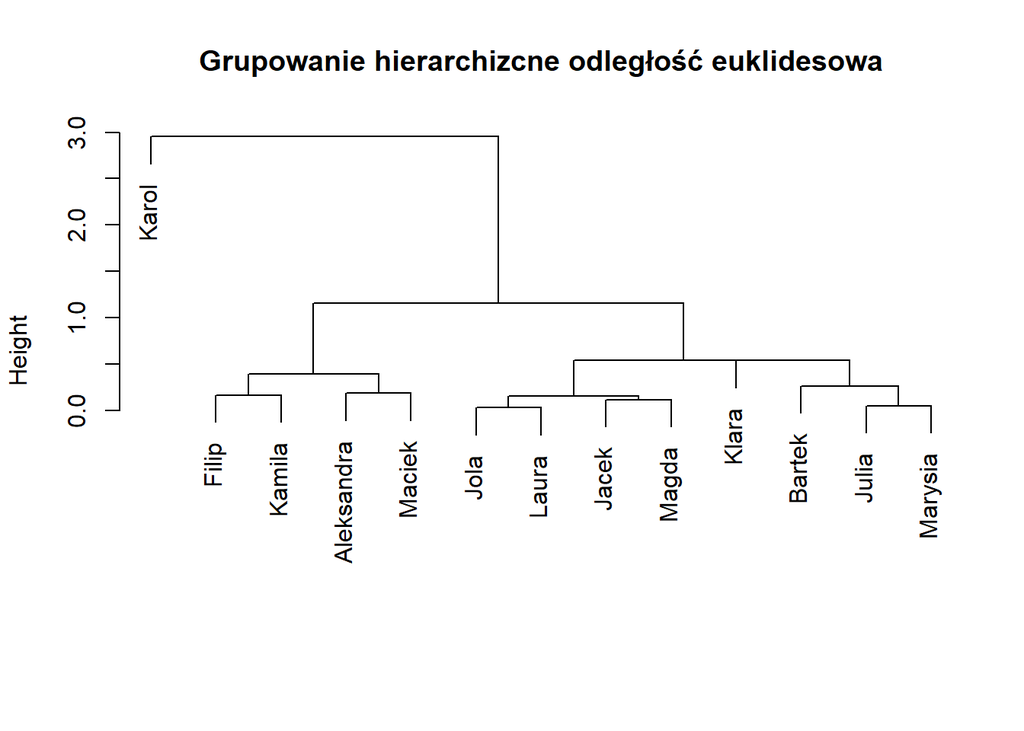

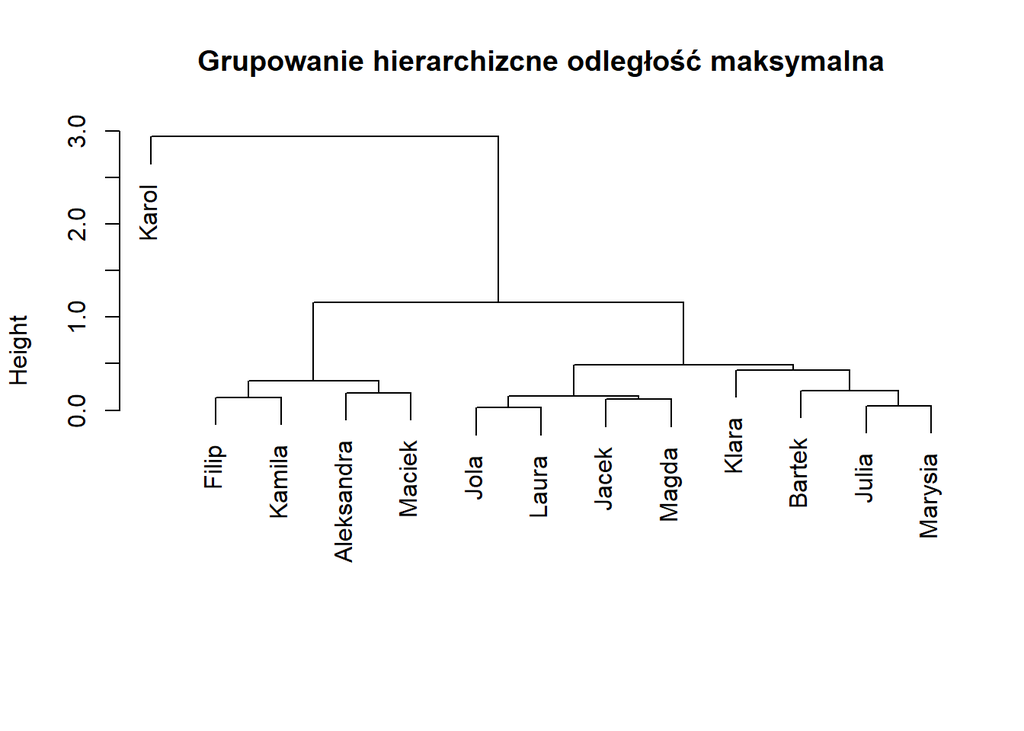

Warto też dodać że zamiana odległości na odległość maksymalną jedynie w małym stopniu zmieniła posiom skupień poszczególnych grup, lecz nie wpłynęła na zmianę ich składu

# Skalowanie wielowymiarowe

Poprzednie grupowania, zostały wykonane względem dwóch zmiennych, tak że wyniki można było przedstawic na wykresie.

Teraz chcąc uwzględnić więcej zmiennych na raz, należy sięgnąć do technik skalowania wielowymiarowego. Zostaną przedstawione dwie techniki: Klasyczne skalowanie wielowymiarowe oraz Mapowanie Sammona.

Obie z metod korzystają z odległości euklidesowych, jednak Skalowanie Sammona znacznie lepiej obrazuje małe odległości. Spodziewana jest zatem rozbieżność uzyskanych wyników.

Wszystkie techniki skalowania wielowymiarowego opierają się na dystansach. Jednak dzięki temu skalowaniu, odległości 4 wymiarowe (między 4 zmienymi) zostały przeskalowane tak, aby można było zobaczyć je w przestrzeni wielowymiarowej.

Dla tak przeskalowanych wyników zastosowano metodę grupowania k-średnich. Podziały można zobaczyć poniżej:

```r
library(MASS)
```

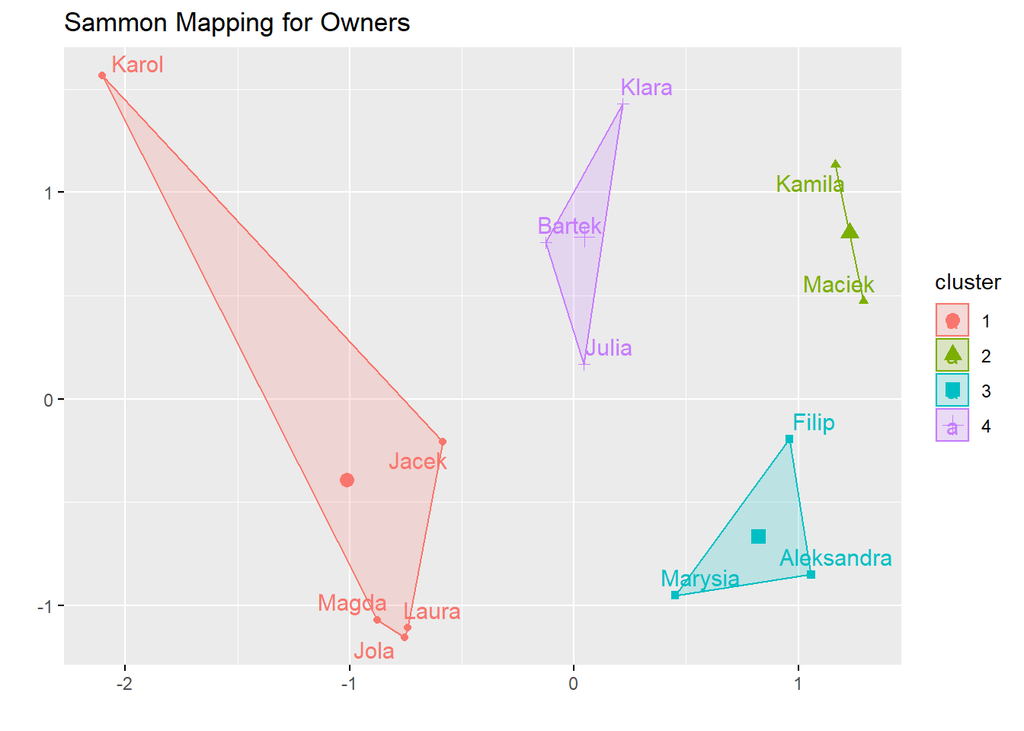

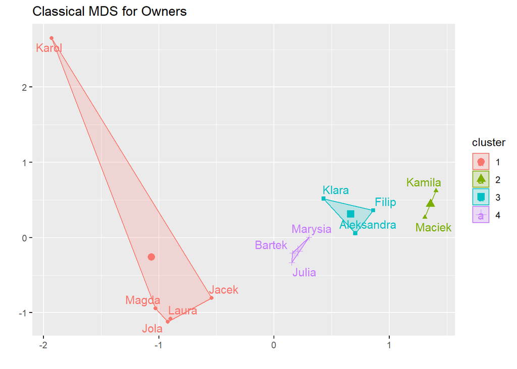

```
## Initial stress        : 0.02596
## stress after  10 iters: 0.00708, magic = 0.500
## stress after  20 iters: 0.00694, magic = 0.500
## stress after  30 iters: 0.00693, magic = 0.500
```

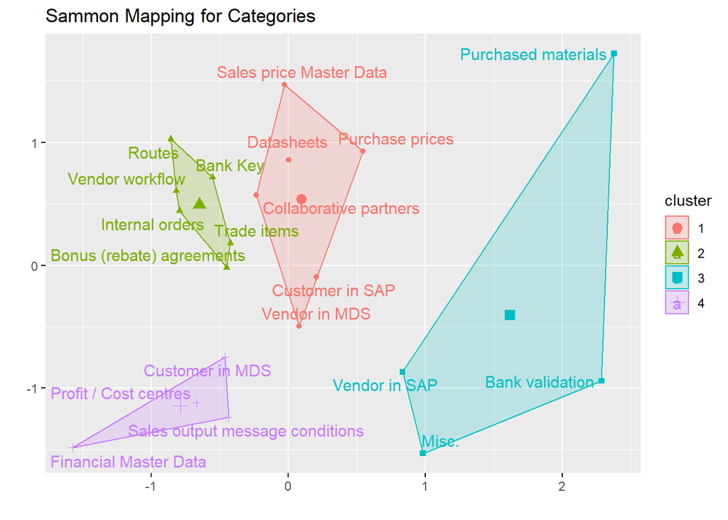

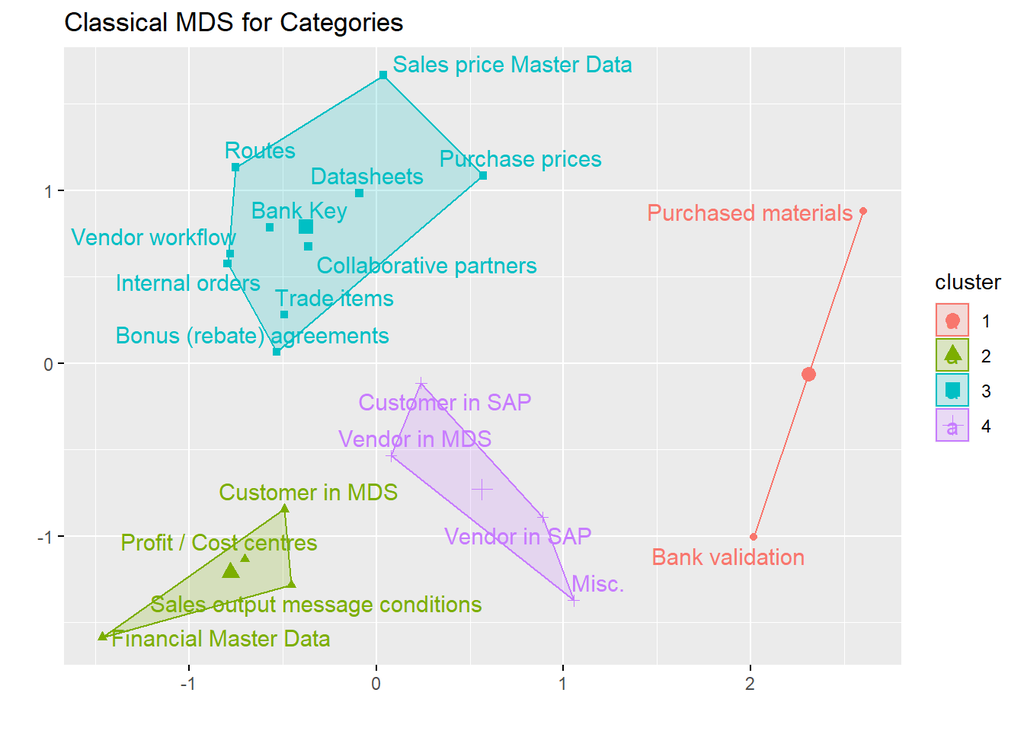

# Podsumowanie

Biorąc pod uwagę uzyskane wyniki, zarówno z rankingów jak i metod grupowania i skalowania. Można jednoznacznie stwierdzić, że najlepszymi pracownikami są Kamila i Maciek.

Można zatem przyjąć, że największa pomoc przydałaby się w zadaniach związanych z kategoriami Bank Validation oraz Purchased Materials, a największa pochwała nalezy się Kamili i Maćkowi.